# hdt4

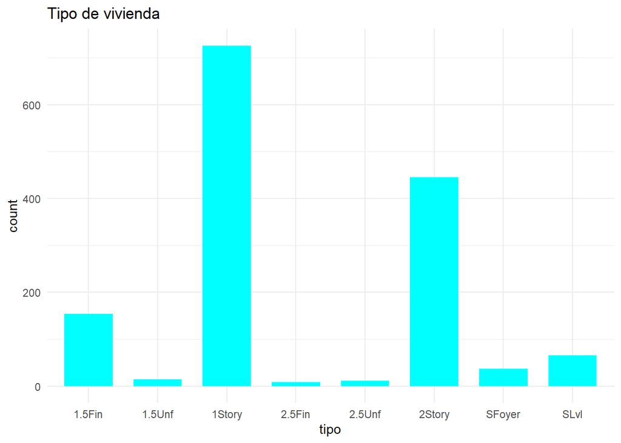

```r
library(ggplot2)
df <- as.data.frame(casas$HouseStyle)
tipo <-casas$HouseStyle
mostrar <- (ggplot(data=df, aes(x=tipo)) + geom_bar(stat="count", width=0.7, fill = "cyan")+theme_minimal())
print(mostrar + ggtitle("Tipo de vivienda"))
```

Con este grafico podemos observar que el tipo de vivienda más comun es de 1 nivel

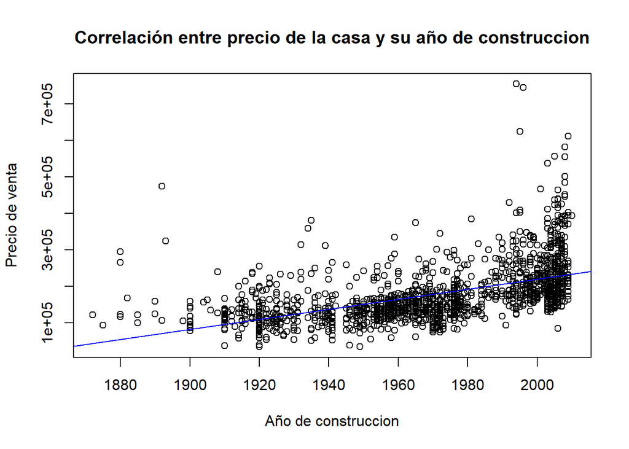

```r
plot(x = casas$YearBuilt, y= casas$SalePrice, xlab= "Año de construccion", ylab= "Precio de venta", main = "Correlación entre precio de la casa y su año de construccion")
abline(lm(casas$SalePrice ~ casas$YearBuilt), col = "blue")
```

Con estos graficos podemos observar que existe una relacion entre el precio al que se venden las casas con respecto al año al que fueron construidas.

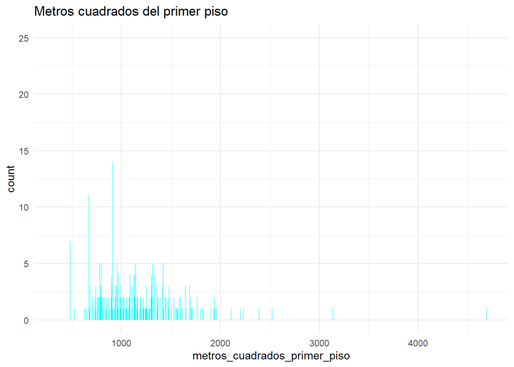

```r
library(ggplot2)
df <- as.data.frame(casas$X1stFlrSF)
metros_cuadrados_primer_piso <- casas$X1stFlrSF
mostrar <- ggplot(data=df, aes(x=metros_cuadrados_primer_piso)) + geom_bar(stat="count", width=0.7, fill = "cyan")+theme_minimal()
print(mostrar + ggtitle("Metros cuadrados del primer piso"))
```

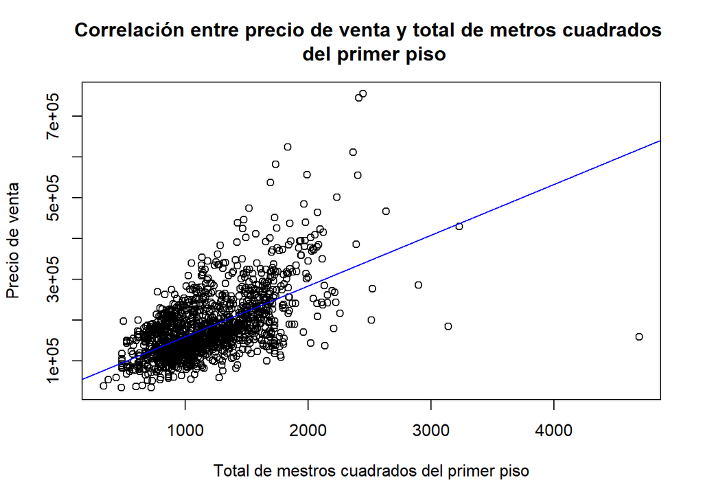

```r
plot(x = casas$X1stFlrSF, y= casas$SalePrice, xlab= "Total de mestros cuadrados del primer piso", ylab= "Precio de venta", main = "Correlación entre precio de venta y total de metros cuadrados \n del primer piso")
abline(lm(casas$SalePrice ~ casas$X1stFlrSF), col = "blue")
```

Podemos observar que existe una relación entre el precio de venta y el tamaño en M^2 del primer piso de la casa.

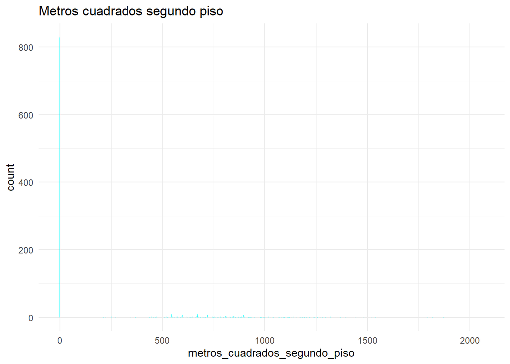

```r
library(ggplot2)
df <- as.data.frame(casas$X2ndFlrSF)
metros_cuadrados_segundo_piso <- casas$X2ndFlrSF
mostrar <- ggplot(data=df, aes(x=metros_cuadrados_segundo_piso)) + geom_bar(stat="count", width=0.7, fill = "cyan")+theme_minimal()
print(mostrar + ggtitle("Metros cuadrados segundo piso"))
```

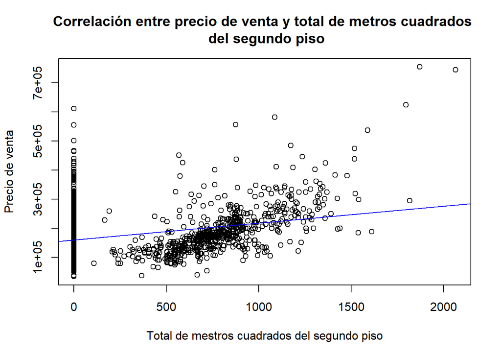

```r
plot(x = casas$X2ndFlrSF, y= casas$SalePrice, xlab= "Total de mestros cuadrados del segundo piso", ylab= "Precio de venta", main = "Correlación entre precio de venta y total de metros cuadrados \n del segundo piso")
abline(lm(casas$SalePrice ~ casas$X2ndFlrSF), col = "blue")
```

Como podemos observar, tambien existe una relacion entre el tamaño en M^2 del segundo nivel de una casa y su precio.

```r
casas_num <- sapply(casas, is.numeric)
casas_num <- select_if(casas, is.numeric)
casas_num <- casas_num[complete.cases(casas_num),]
casas_num <- scale(na.omit(casas_num))
set.seed(123)
hopkins(casas_num)
```

```
## [1] 1
```